# R for Data Science exercises

## Exercises 10.5.3.1

### Instead of summarizing the conditional distribution with a boxplot, you could use a frequency polygon. What do you need to consider when using cut_width() vs. cut_number()? How does that impact a visualization of the 2d distribution of carat and price?

The significant difference is the category of the groups formed. The function `cut_number()` cuts the data following a specific number of observations a determined sample size. Likewise, the function `cut_width()` cuts the database into bins with a determined width. This creates a faux categorical variable from a continuous dataset.

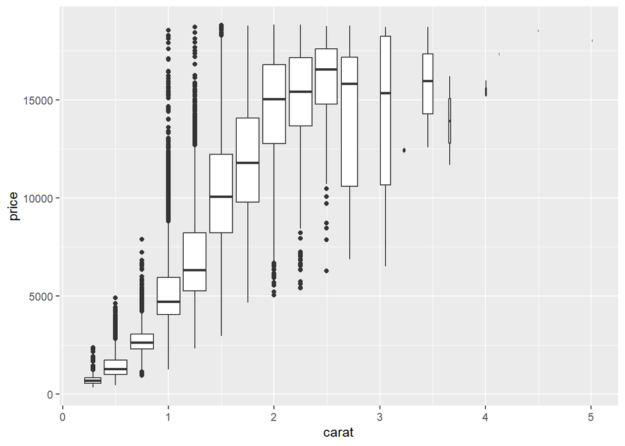

```r
#cut_width
ggplot(diamonds, aes(x = carat, y = price)) +
  geom_boxplot(aes(group = cut_width(carat, 0.25)))
```

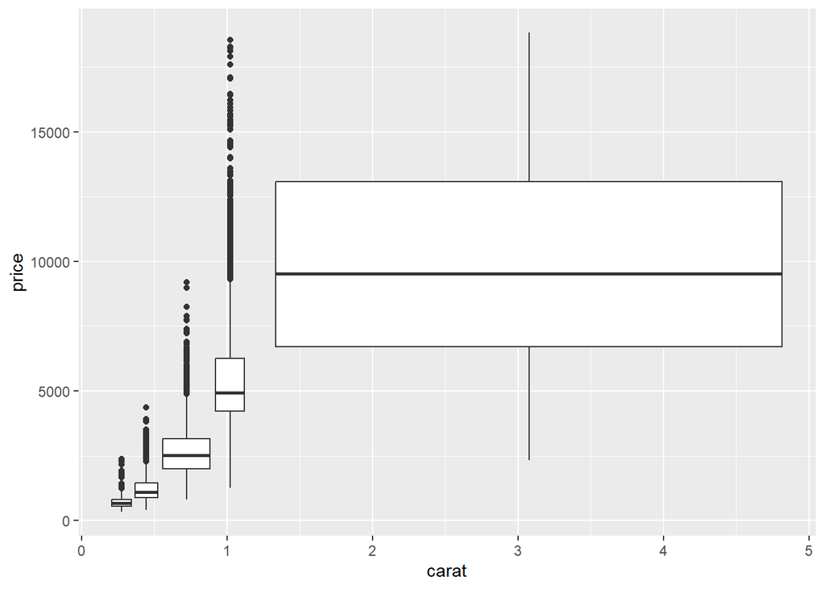

```r
#Cut_number
ggplot(diamonds, aes(x = carat, y = price)) +
  geom_boxplot(aes(group = cut_number(diamonds$carat, n =5)))
```

The usage of each of them reveals a different aspect of the data. The function `cut_width()` allows you to create bins with a specific width, without worrying about the number of observations in each bin. On the other hand, the function `cut_number()` works by setting groups with the same number of observations, even though the widths are different.

### Visualize the distribution of carat, partitioned by price.

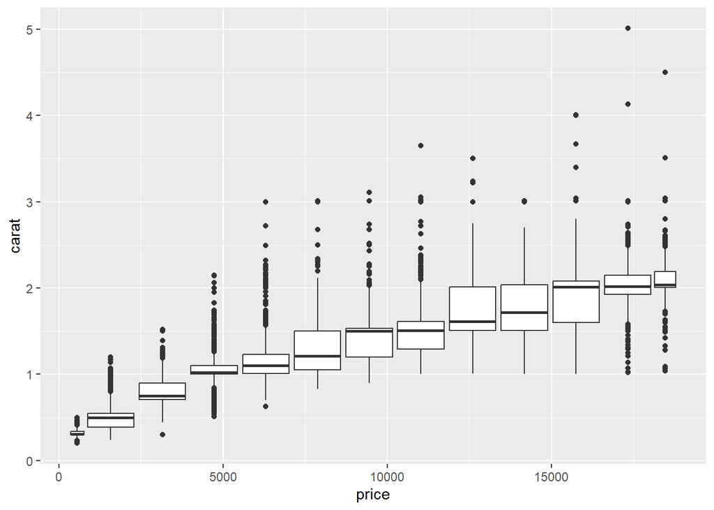

```r
#cut_width
ggplot(diamonds, aes(x = price, y =carat )) +
  geom_boxplot(aes(group = cut_width(price, 1575)))
```

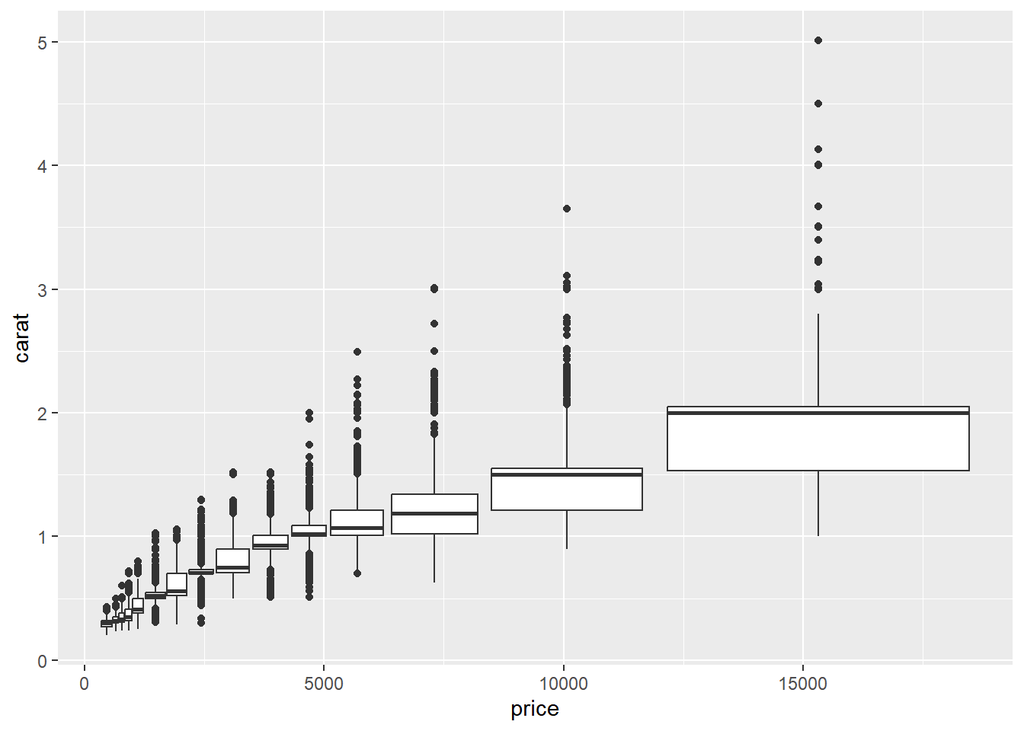

```r
#Cut_number
ggplot(diamonds, aes(x = price, y =carat )) +
  geom_boxplot(aes(group = cut_number(diamonds$price, n =15)))
```

### How does the price distribution of very large diamonds compare to small diamonds? Is it as you expect, or does it surprise you?

The database shows that the higher the price, the larger the carat. I suspected this behavior was true because diamonds are very difficult to find; therefore, since larger diamonds are harder to find, they are worth more. What surprised me is that the cut also influences the price. Better cuts can cost less than lower-quality cuts if the latter have a larger carat weight.

### Combine two of the techniques you’ve learned to visualize the combined distribution of cut, carat, and price.

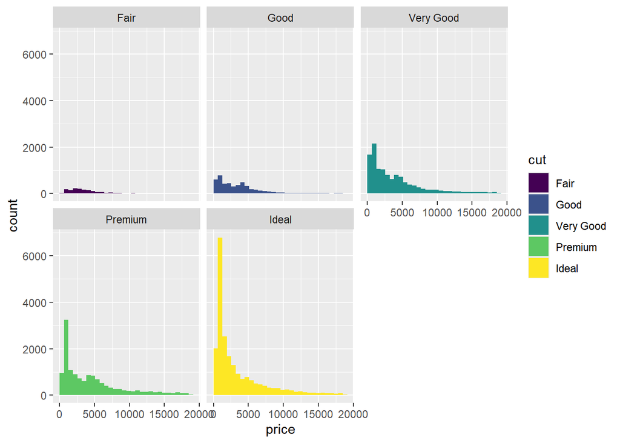

```r
ggplot(diamonds, aes(x = price, fill = cut)) +
  geom_histogram() +
  facet_wrap(~cut)
```

### Two dimensional plots reveal outliers that are not visible in one dimensional plots. For example, some points in the following plot have an unusual combination of x and y values, which makes the points outliers even though their x and y values appear normal when examined separately. Why is a scatterplot a better display than a binned plot for this case?

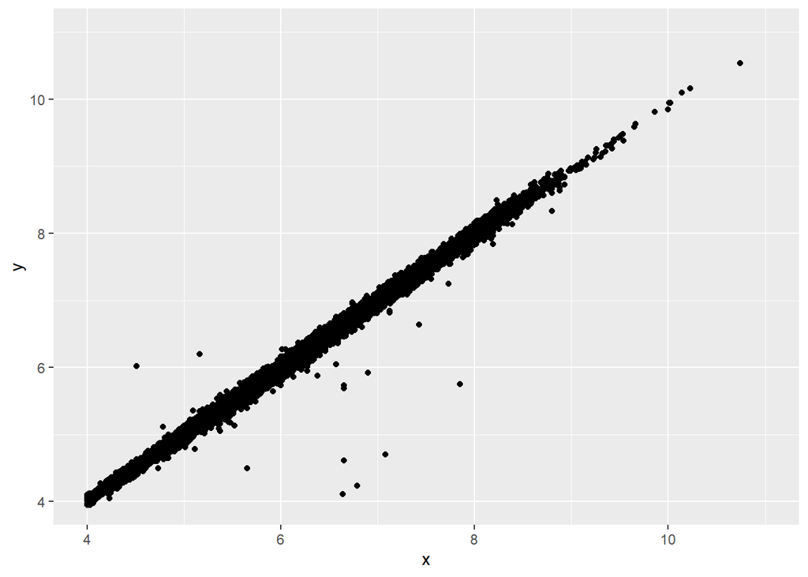

```r
diamonds |>
  filter(x >= 4) |>
  ggplot(aes(x = x, y = y)) +
  geom_point() +
  coord_cartesian(xlim = c(4, 11), ylim = c(4, 11))
```

Scatterplots mix these two dimensions. If a value is not anomalous, it is supposed to be close to the central line, which represents a common linear relationship. Binned analysis would mask this value depending on the size of the bin. If the width were large enough to contain these points (for example, using `cut_width()`), they would not appear. In another possible scenario, a database where the number of observations inside each bin is high could contain those putative outliers, masking them from the analysis.

### Instead of creating boxes of equal width with `cut_width()`, we could create boxes that contain roughly equal number of points with `cut_number()`. What are the advantages and disadvantages of this approach?

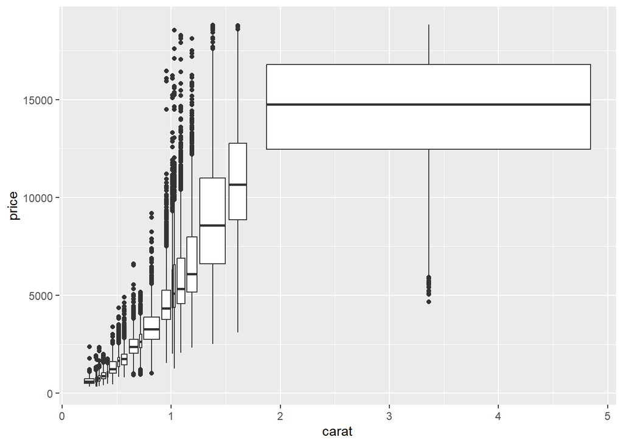

```r
ggplot(diamonds, aes(x = carat, y = price)) +
  geom_boxplot(aes(group = cut_number(carat, 20)))
```

Using the function `cut_number()` can be advantageous when the data being analyzed has large gaps between values. Since each bin must contain a specific number of observations, these gaps can be easily overlooked. However, when there is a high frequency of identical or very similar values across different objects, this approach may create too many bins containing the same values, which is not informative.

The advantages of the `cut_width()` function are exactly the opposite of the disadvantages of `cut_number()`. Large datasets with many repeated values for different observations can be clustered into a single bin by adjusting its width. The major disadvantage of using this function is the masking of outliers. If the bin width is sufficiently large while the data is sparse, outliers may be merged into the bin and treated as normal data.